# Gráficas ggplot2

Kenneth Roy Cabrera Torres

martes, 17 de marzo de 2015

## ¿Qué es ggplot2? I

- Es una construcción de la “Gramática de las gráficas” (Grammar Graphics) propuesta por Leland Wilkinson.
- Escrito por Hadley Wickham (como estudiante de Iowa State).
- Está disponible en CRAN y se installa como un paquete del CRAN.
- La gramática de las gráficas representa una abtracción de gráficas e ideas.
- Similar a pensar en “verbos”, “sustantivos” y “adjetivos” para las gráficas.
- La teoría propone una construcción de gráficas mediante una sucesión de elementos similar a un lenguaje.
- La idea es acortar la distancia entre lo que se piensa y lo que se grafica.

“En resumen, la gramática nos dice que una gráfica estadística es un mapa de los datos a unos atributos estéticos (color, forma, tamaño) de unos objetos geométricos (puntos, lineas, barras). La gráfica tendrá transformaciones estadísticas que se trazan en sistemas de coordenadas específicas”

Del libro “ggplot2”

## La función qplot()

- Trabaja similar a la función *plot* en el sistema básico.
- Se le indica una base de datos, unos elementos *estéticos* y una *geometría*.
- Se recomienda trabajar con la composición para tener más dominio de la gramática.

## Paquete ggplot2

```r
require(ggplot2)
```

## Lectura y adecuación de la base de datos

```r
enc   <- read.csv2("Encuesta.csv", enc = "latin1", na.string = "Sin Resp.")
habitos <- names(subset(enc,select=H01_Casa:H16_ResuelveSolo))
habitosB <- habitos[c(3,5,7,9,12,16)]
habitosM <- habitos[!(habitos %in% habitosB)]
enc$NHabB <- apply(subset(enc, select=habitosB),1,sum,na.rm=TRUE)
enc$NHabM <- apply(subset(enc, select=habitosM),1,sum,na.rm=TRUE)
temp1 <- subset(enc, select=H01_Casa:H16_ResuelveSolo)
temp2 <- stack(temp1)
names(temp2) <- c("Usa","HabitoEstudio")
enc2  <- subset(enc, select=c(NroEnc:HorasTotal,Horas_Deporte:NHabM))
enc3  <- data.frame(enc2[rep(1:nrow(enc),ncol(temp1)),],temp2)
enc3$TipoHabito <- (enc3$HabitoEstudio %in% habitosB)*1
enc3$TipoHabito <- factor(enc3$TipoHabito,labels=c("No Recom","Recom"))
```

## Gráfica de dispersión 1

Gráfica de dispersión simple.

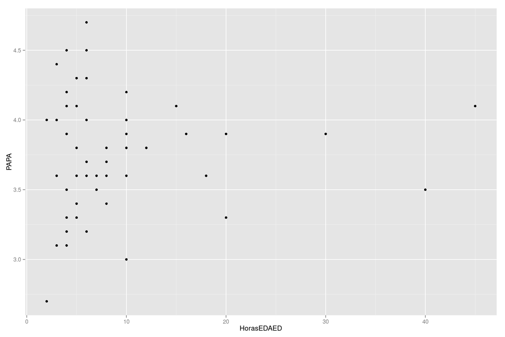

```r
require(ggplot2)
g1 <- ggplot(enc, aes(HorasEDAED, PAPA))
g1 + geom_point()
```

## Gráfica de dispersión 2

Cambiando el tamaño del punto

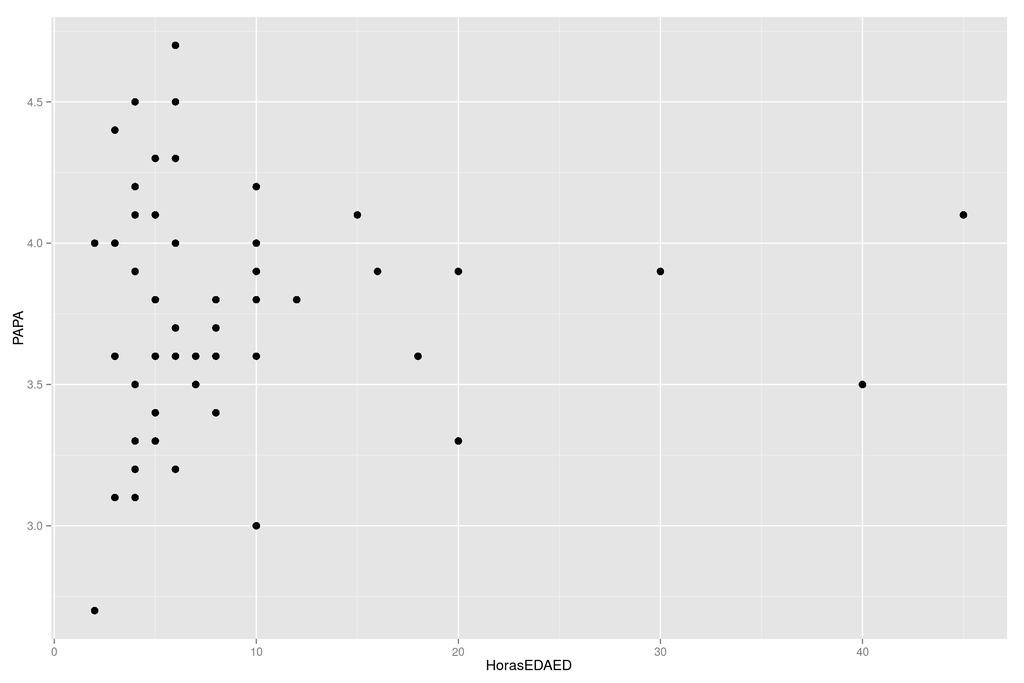

```r
require(ggplot2)
g1 <- ggplot(enc, aes(HorasEDAED, PAPA))
g1 + geom_point(size=3)
```

## Gráfica de dispersión 3

Coloreando por Carrera

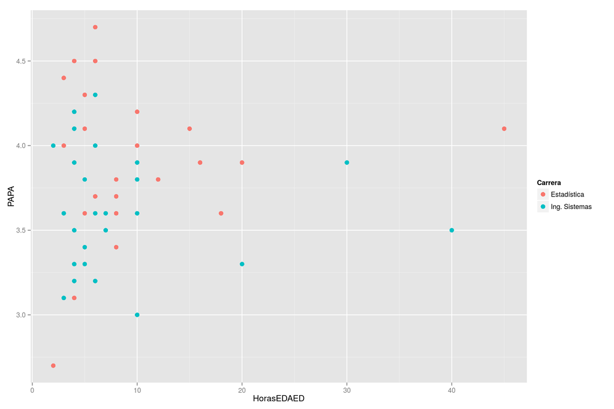

```r
require(ggplot2)
g1 <- ggplot(enc, aes(HorasEDAED, PAPA, col = Carrera))
g1 + geom_point(size=3)
```

## Gráfica de dispersión con suavizamiento 1

Añadiendo un nuevo **geom_**

```
## geom_smooth: method="auto" and size of largest group is <1000, so using loess. Use 'method = x' to change the smoothing method.
```

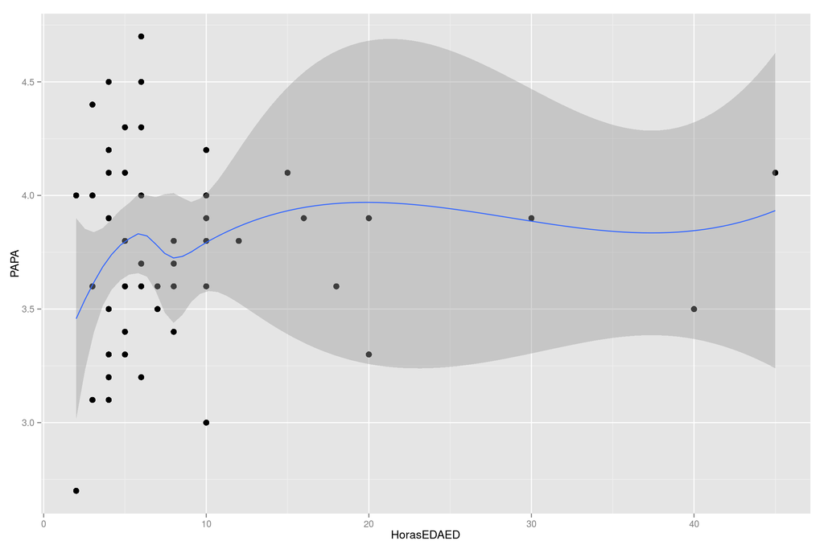

```r
require(ggplot2)
g1 <- ggplot(enc, aes(HorasEDAED, PAPA))
g1 + geom_point(size=3) + geom_smooth()
```

## Gráfica de dispersión con suavizamiento 2

Añadiendo un nuevo **geom_** y color por carrera

```
## geom_smooth: method="auto" and size of largest group is <1000, so using loess. Use 'method = x' to change the smoothing method.
```

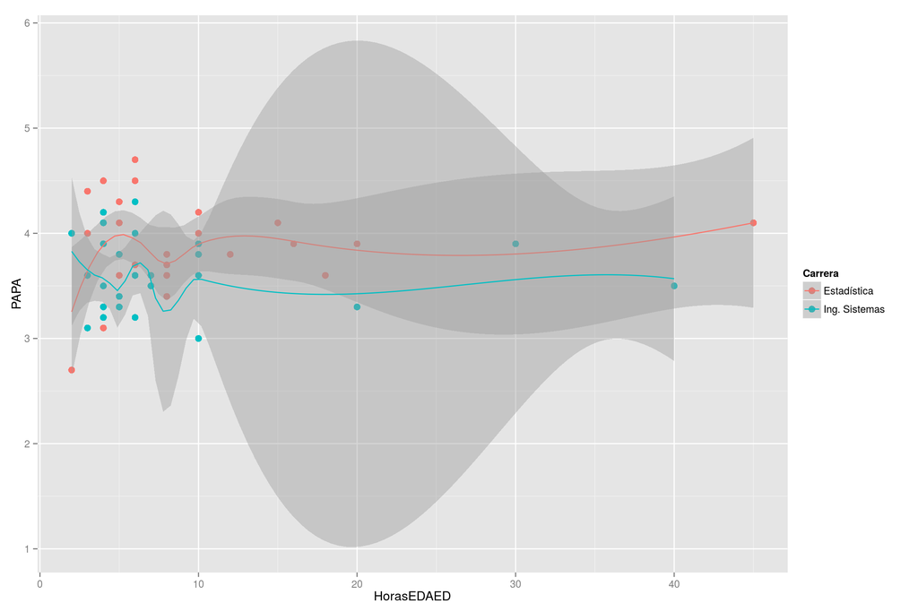

```r
require(ggplot2)
g1 <- ggplot(enc, aes(HorasEDAED, PAPA, col = Carrera))
g1 + geom_point(size=3) + geom_smooth()
```

## Gráfica de dispersión con suavizamiento 3

Añadiendo un nuevo **geom_** y color por carrera y en una subase de datos.

```
## geom_smooth: method="auto" and size of largest group is <1000, so using loess. Use 'method = x' to change the smoothing method.
```

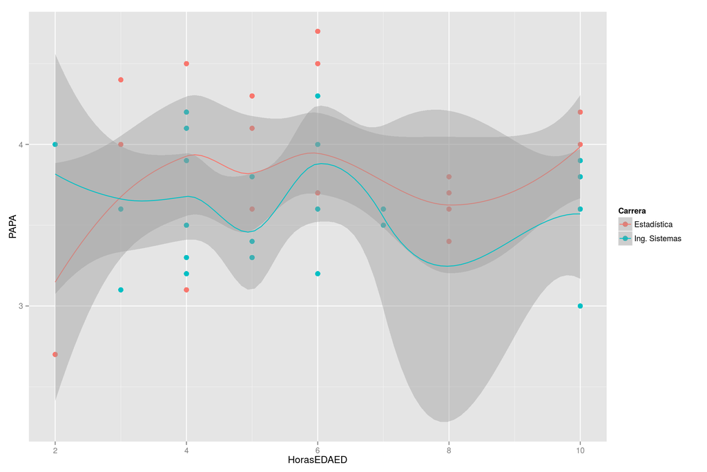

```r
require(ggplot2)
g1 <- ggplot(subset(enc,HorasEDAED <=10), aes(HorasEDAED, PAPA, col = Carrera))
g1 + geom_point(size=3) + geom_smooth()
```

## Histograma

```
## stat_bin: binwidth defaulted to range/30. Use 'binwidth = x' to adjust this.
```

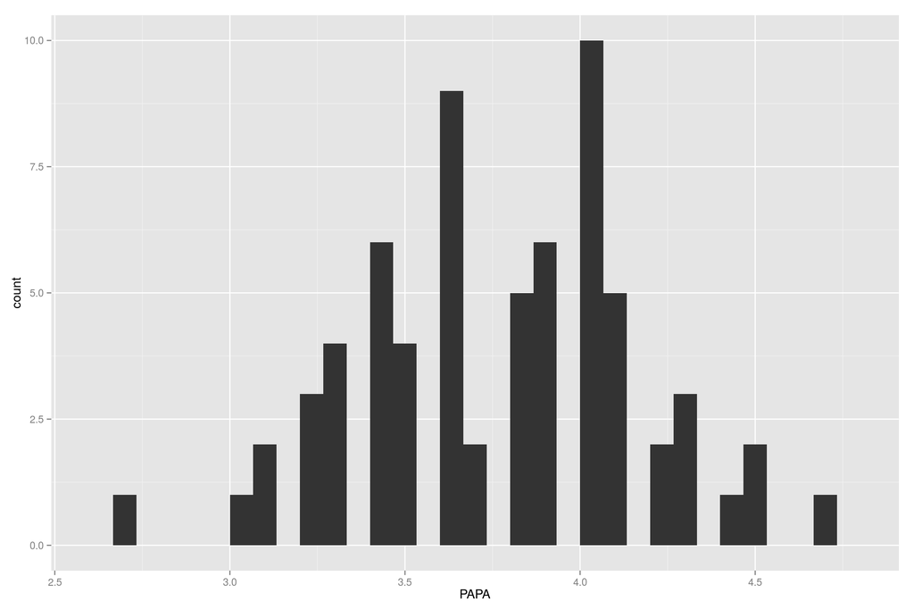

```r
require(ggplot2)
g1 <- ggplot(enc, aes(PAPA))
g1 + geom_histogram()
```

## Histogramas

```
## stat_bin: binwidth defaulted to range/30. Use 'binwidth = x' to adjust this.
```

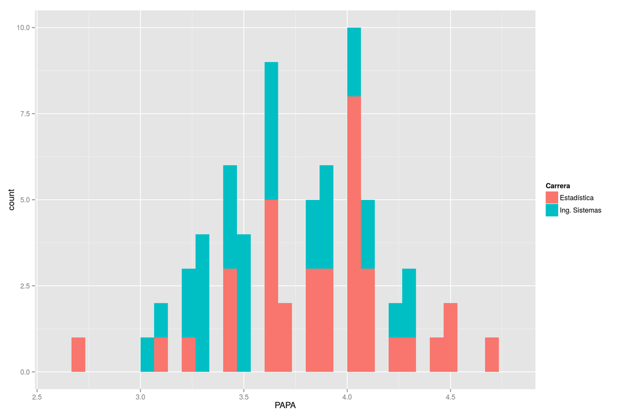

```r
require(ggplot2)
g1 <- ggplot(enc, aes(PAPA, fill=Carrera))
g1 + geom_histogram()
```

## Facetas I

```
## stat_bin: binwidth defaulted to range/30. Use 'binwidth = x' to adjust this.
## stat_bin: binwidth defaulted to range/30. Use 'binwidth = x' to adjust this.
```

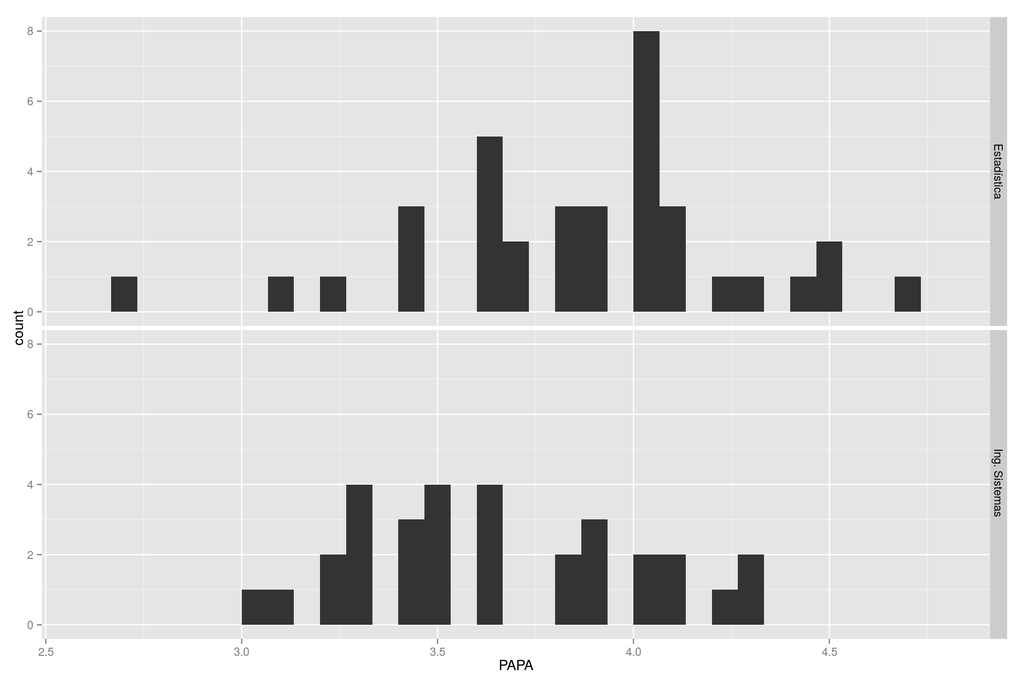

```r
require(ggplot2)
g1 <- ggplot(enc, aes(PAPA))
g1 + geom_histogram() + facet_grid(Carrera ~ .)
```

## Con Densidades I

Diferentes densidades para cada Carrera

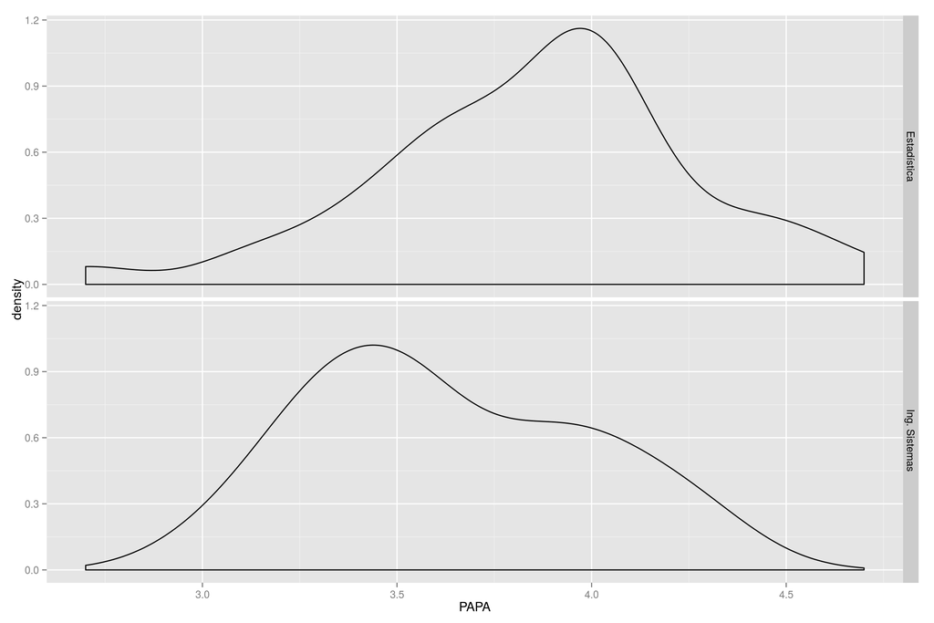

```r
require(ggplot2)
g1 <- ggplot(enc, aes(PAPA))
g1 + geom_density() + facet_grid(Carrera ~ .)
```

## Con Densidades II

Diferentes densidades para cada Carrera por columna.

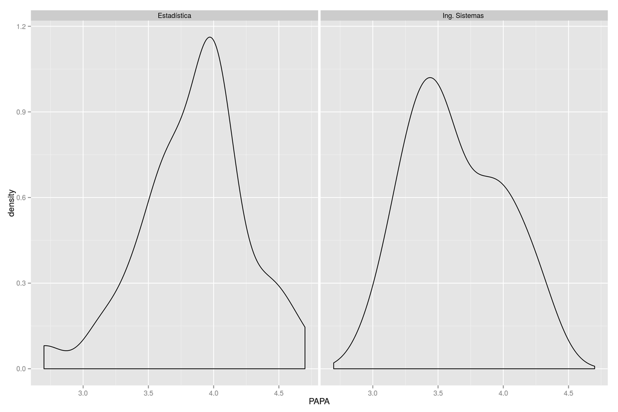

```r
require(ggplot2)
g1 <- ggplot(enc, aes(PAPA))
g1 + geom_density() + facet_grid(. ~ Carrera)
```

## Con Densidades II

Diferentes densidades para cada Carrera

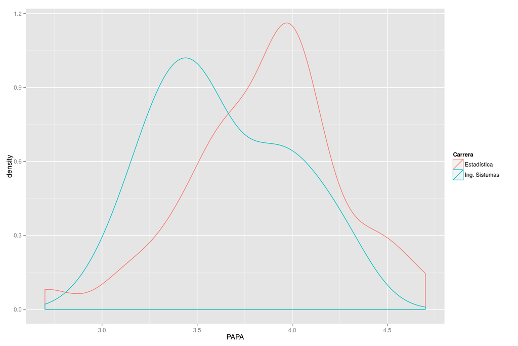

```r
require(ggplot2)
g1 <- ggplot(enc, aes(PAPA, col = Carrera))
g1 + geom_density()
```

## Número de hábitos malos

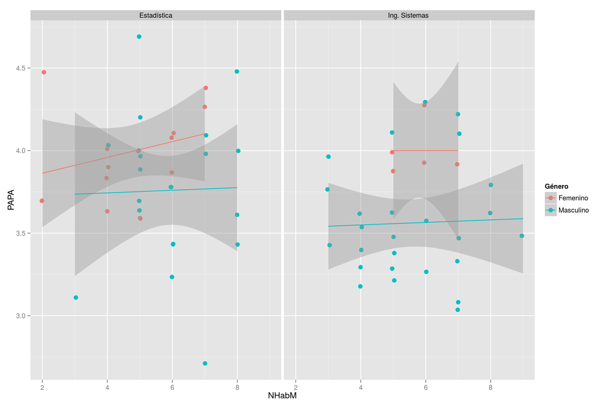

```r
require(ggplot2)
g1 <- ggplot(enc, aes(NHabM, PAPA, col = Género))
g1 + geom_jitter(size = 3, position = position_jitter(width = .05)) +
     geom_smooth(method="lm") +
     facet_grid(. ~ Carrera)
```

## Número de hábitos buenos

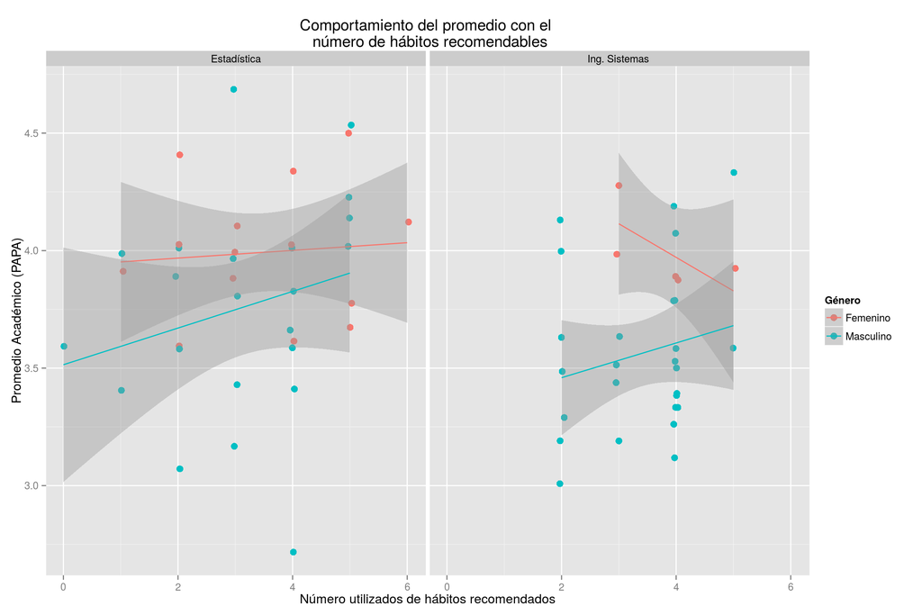

```r
require(ggplot2)
g1 <- ggplot(enc, aes(NHabB, PAPA, col = Género))
g1 + geom_jitter(size = 3, position = position_jitter(width = .05)) +
     geom_smooth(method="lm") +
     facet_grid(. ~ Carrera) +
     ggtitle("Comportamiento del promedio con el \n número de hábitos recomendables")+
     ylab("Promedio Académico (PAPA)") +
     xlab("Número utilizados de hábitos recomendados")
```

## Clasificación de los tipos de hábitos

```r
# Promedio del PAPA por habito de estudio
(promXHab <- with(subset(enc3,Usa==1),tapply(PAPA,HabitoEstudio, median)))
```

```
##         H01_Casa    H02_Notas_lin      H03_Horario       H04_Musica
##             3.80             3.80             3.90             3.80
##   H05_Lugar_Fijo          H06_Lee     H07_TemasDif       H08_Amigos
##             3.80             3.60             3.80             3.90
##       H09_Pausas    H10_Trasnocha      H11_Subraya  H12_Duerma_bien
##             3.70             3.50             3.90             3.80
##       H13_Margen     H14_Memoriza H15_Solucionario H16_ResuelveSolo
##             3.90             3.60             3.60             3.85
```

```r
# Ordenar de mayor a menor
(promXHab <- sort(promXHab, decreasing=T))
```

```
##      H03_Horario       H08_Amigos      H11_Subraya       H13_Margen
##             3.90             3.90             3.90             3.90
## H16_ResuelveSolo         H01_Casa    H02_Notas_lin       H04_Musica
##             3.85             3.80             3.80             3.80
##   H05_Lugar_Fijo     H07_TemasDif  H12_Duerma_bien       H09_Pausas
##             3.80             3.80             3.80             3.70
##          H06_Lee     H14_Memoriza H15_Solucionario    H10_Trasnocha
##             3.60             3.60             3.60             3.50
```

```r
(NOrdPxH <- names(promXHab))
```

```
##  [1] "H03_Horario"      "H08_Amigos"       "H11_Subraya"
##  [4] "H13_Margen"       "H16_ResuelveSolo" "H01_Casa"
##  [7] "H02_Notas_lin"    "H04_Musica"       "H05_Lugar_Fijo"
## [10] "H07_TemasDif"     "H12_Duerma_bien"  "H09_Pausas"
## [13] "H06_Lee"          "H14_Memoriza"     "H15_Solucionario"
## [16] "H10_Trasnocha"
```

[output not shown]

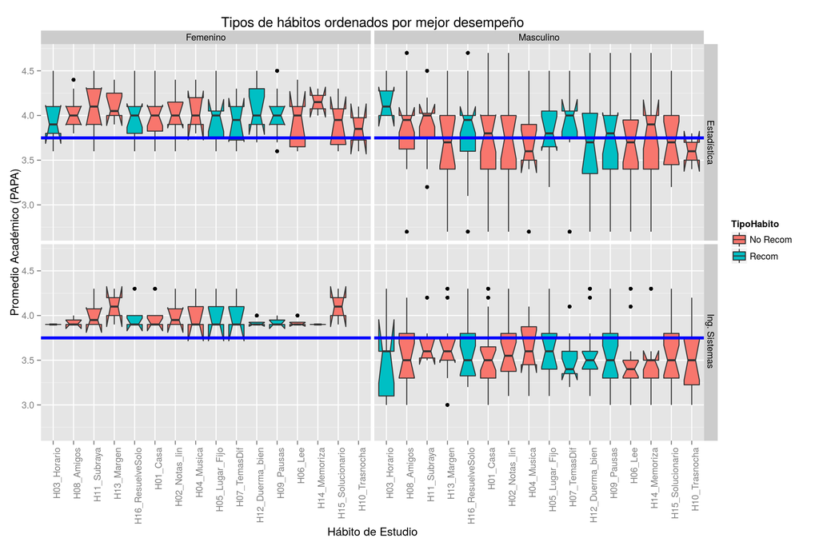

```r
# Reordenar los niveles del factor TipoHabito
enc3$HabitoEstudio <- factor(enc3$HabitoEstudio,levels=NOrdPxH)
require(ggplot2)
g1 <- ggplot(subset(enc3,Usa==1), aes(HabitoEstudio, PAPA, fill=TipoHabito))
g1 + geom_boxplot(notch=TRUE) +
    theme(axis.text.x = element_text(angle = 90, hjust = 1))+
    geom_abline(intercept = mean(enc$PAPA,na.rm=TRUE), slope=0, col="blue", size=1.5) +
    facet_grid(Carrera ~ Género) +
    ggtitle("Tipos de hábitos ordenados por mejor desempeño") +
    ylab("Promedio Académico (PAPA)") +
    xlab("Hábito de Estudio")
```

## Referencias

- Página oficial del paquete (http://ggplot2.org).
- Página de recetas (http://www.cookbook-r.com/Graphs/).
- Referencia rápida (http://sape.inf.usi.ch/quick-reference/ggplot2).
- Foro de ayuda (http://groups.google.com/group/ggplot2).
- Foro de desarrollo (http://github.com/hadley/ggplot2).